# Lab 6

Author

Mark Tello-Rincon

### Set-up

```r
library(tidytext)
library(readr)
library(dplyr)
library(ggplot2)
library(tidyr)


mt_samples <- read_csv("https://raw.githubusercontent.com/USCbiostats/data-science-data/master/00_mtsamples/mtsamples.csv")
mt_samples <- mt_samples |>
  select(description, medical_specialty, transcription)

head(mt_samples)
```

```
# A tibble: 6 × 3
  description                                    medical_specialty transcription
  <chr>                                          <chr>             <chr>
1 A 23-year-old white female presents with comp… Allergy / Immuno… "SUBJECTIVE:…
2 Consult for laparoscopic gastric bypass.       Bariatrics        "PAST MEDICA…
3 Consult for laparoscopic gastric bypass.       Bariatrics        "HISTORY OF …
4 2-D M-Mode. Doppler.                           Cardiovascular /… "2-D M-MODE:…
5 2-D Echocardiogram                             Cardiovascular /… "1.  The lef…
6 Morbid obesity.  Laparoscopic antecolic anteg… Bariatrics        "PREOPERATIV…
```

### Question 1

How many different categories do we have in the data. Are these categories related? Overlapping? Evenly distributed?

- There are 40 categories in the dataset.
- Few categories are related and appear to be mostly general documentation, i.e., nursing reports, including:
  - `Consult - History and Phy.`
  - `SOAP / Chart / Progress Notes`
  - `Discharge Summary`
  - `Emergency Room Reports`
  - `Office Notes`
  - `Letters`
  - `IME-QME-Work Comp etc.`
  - `Diets and Nutritions`
- This dataset is not evenly distributed as `Surgery` has the most medical transcriptions, with 1103, with the second most being `Consult - History and Phy.` with 516, and `Cardiovascular/Pulmonary` with 372.

```r
mt_samples %>%
  count(medical_specialty, sort = TRUE) %>%
  print(n = 40)
```

```
# A tibble: 40 × 2
   medical_specialty                 n
   <chr>                         <int>
 1 Surgery                        1103
 2 Consult - History and Phy.      516
 3 Cardiovascular / Pulmonary      372
 4 Orthopedic                      355
 5 Radiology                       273
 6 General Medicine                259
 7 Gastroenterology                230
 8 Neurology                       223
 9 SOAP / Chart / Progress Notes   166
10 Obstetrics / Gynecology         160
11 Urology                         158
12 Discharge Summary               108
```

[output cut: 28 more lines]

### Question 2

Explain what we see from this result. Does it makes sense? What insights (if any) do we get?

- Almost all top 20 words are considered function or stop words (i.e., articles, prepositions, pronouns, verbs, conjunctions) since they are primarily used to structure sentences.
- Others, such as `patient` and `right` are nouns/adjectives.
- This does make sense, since most of medical transcription is mostly made up of function words to describe things that are occurring, or where things are, ex., the patient, medications, IV placements, procedures, diagnostics, vitals, symptoms, etc.

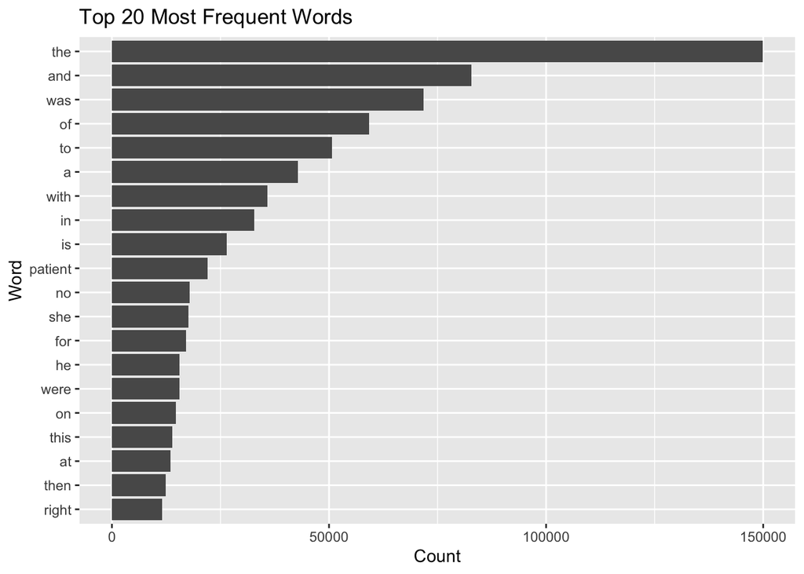

```r
mt_samples %>%
  unnest_tokens(word,transcription) %>%
  count(word,sort=TRUE) %>%
  top_n(20,n) %>%
  ggplot(aes(x=reorder(word,n),y=n))+
  geom_col()+
  coord_flip()+
  labs(x="Word",y="Count",title="Top 20 Most Frequent Words")
```

### Question 3

What do we see know that we have removed stop words? Does it give us a better idea of what the text is about?

- Without stop words (or numbers), it can be seen that most words are medical terms, directional terms, verbs, measurements, and descriptors.
- This gives a clearer picture that this dataset is about medical transcription, especially considering the heavy use of medical and directional terms, as well as measurements.

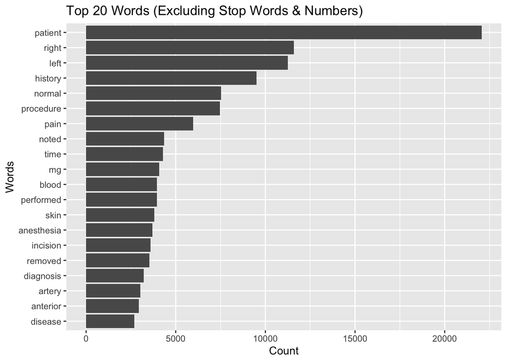

```r
mt_samples %>%
  unnest_tokens(word, transcription) %>%
  anti_join(stop_words %>% filter(!word %in% c("right", "left")), by = "word") %>%
  filter(!grepl("^[0-9]+$", word)) %>%
  count(word, sort = TRUE) %>%
  top_n(20, n) %>%
  ggplot(aes(x=reorder(word, n), y =n)) +
  geom_col() +
  coord_flip() +
  labs(x="Words", y="Count", title="Top 20 Words (Excluding Stop Words & Numbers)")
```

### Question 4

Repeat question 2, but this time tokenize into bi-grams. How does the result change if you look at tri-grams?

- The bi-gram shows mostly combined stop words, whereas the tri-gram provides a little more insight into the transcriptions, with short phrases describing things, i.e., `the patient is`, `the operating room`, `prepped and draped`, `at this time`. The tri-gram is more descriptive, with the most common phrases being combinations of stop words and nouns/verbs/adjectives.

```r
## bi-gram
mt_samples %>%
  unnest_tokens(bigram, transcription, token = "ngrams", n=2) %>%
  count(bigram, sort = TRUE) %>%
  top_n(20,n)
```

```
# A tibble: 20 × 2
   bigram          n
   <chr>       <int>
 1 the patient 20307
 2 of the      19062
 3 in the      12790
 4 to the      12374
 5 was then     6956
 6 and the      6350
 7 patient was  6293
 8 the right    5509
 9 on the       5241
10 the left     4860
11 with a       4857
12 history of   4537
13 to be        4345
14 is a         4014
15 with the     4002
16 there is     3950
17 at the       3657
18 there was    3334
19 patient is   3332
20 was placed   3328
```

```r
## tri-gram
mt_samples %>%
  unnest_tokens(trigram, transcription, token = "ngrams", n=3) %>%
  count(trigram, sort = TRUE) %>%
  top_n(20,n) %>%
  print(n = 22)
```

```
# A tibble: 22 × 2
   trigram                     n
   <chr>                   <int>
 1 the patient was          6104
 2 the patient is           3075
 3 as well as               2243
 4 there is no              1678
 5 the operating room       1532
 6 patient is a             1491
 7 prepped and draped       1490
 8 was used to              1480
 9 and draped in            1372
10 at this time             1333
11 the patient has          1300
12 to the operating         1156
13 placed in the            1141
14 no evidence of           1132
15 was taken to             1108
16 there was no             1089
17 tolerated the procedure  1066
18 past medical history     1063
19 history of present       1056
20 of present illness       1038
21 of the right             1038
22 was placed in            1038
```

### Question 5

Using the results you got from Question 4, pick a word and count the words that appear before and after it.

- The word I chose is `incision`. The word itself appeared 3601 times.
- `the incision was` appeared 332 times, `skin incision was` appeared 163 times, and `an incision was` appeared 157 times. Any other combination of words with incision in the middle were used less than 100 times.
- The word `incision` had filler/stop words used after it (`and`, `was`), with mostly directional or medical terms having been used before it (ex., `transverse`, `longitudinal`, `midline`, `linear`).

```r
mt_samples %>%
  unnest_tokens(trigram, transcription, token = "ngrams", n = 3) %>%
  separate(trigram, c("word1", "word2", "word3"), sep = " ") %>%
  filter(word2 == "incision") %>%
  count(word1, word2, word3, sort = TRUE)
```

```
# A tibble: 683 × 4
   word1        word2    word3     n
   <chr>        <chr>    <chr> <int>
 1 the          incision was     332
 2 skin         incision was     163
 3 an           incision was     157
 4 the          incision and      76
 5 cm           incision was      74
 6 transverse   incision was      65
 7 this         incision was      64
 8 longitudinal incision was      63
 9 midline      incision was      63
10 linear       incision was      57
# ℹ 673 more rows
```

### Question 6

Which words are most used in each of the specialties? You can use `group_by()` and `top_n()` from `dplyr` to have the calculations be done within each specialty. Remember to remove stop words. What are the 5 most-used words for each specialty?

- The most common words for each specialty typically relate to a specific body region seen by or medical terms used by each specialty; examples:
  - Cardio/Pulm: artery, coronary
  - Derm: skin
  - Diet/Nutrition: weight, carbohydrate
  - ENT: nasal, ear
  - Nephrology: renal, kidney
  - OB/GYN: uterus
  - SOAP/Chart: patient, mg, history, pain
  - Sleep: sleep, apnea
  - Surgery: procedure, anesthesia, incision

```r
mt_samples %>%
  unnest_tokens(word,transcription) %>%
  anti_join(stop_words,by="word") %>%
  filter(!grepl("^[0-9]+$",word)) %>%
  group_by(medical_specialty) %>%
  count(word,sort=TRUE) %>%
  top_n(5, n) %>%
  arrange(medical_specialty,desc(n))
```

```
# A tibble: 210 × 3
# Groups:   medical_specialty [40]
   medical_specialty    word          n
   <chr>                <chr>     <int>
 1 Allergy / Immunology history      38
 2 Allergy / Immunology noted        23
 3 Allergy / Immunology patient      22
 4 Allergy / Immunology allergies    21
 5 Allergy / Immunology nasal        13
 6 Allergy / Immunology past         13
 7 Autopsy              left         83
 8 Autopsy              inch         59
 9 Autopsy              neck         55
10 Autopsy              anterior     47
# ℹ 200 more rows
```

### Question 7

Find your own insight in the data.

#### Admitting Diagnoses for Neonatology

- All cases involved infants or toddlers with prematurity, congenital syndromes, or acute respiratory or gastrointestinal distress
- Upon examining the transcriptions in full, it was found that:
  - Treatment and supportive care (e.g., antibiotics, oxygen, phototherapy) were the main methods of management; these were often initiated before definitive diagnosis

```r
mt_samples %>%
  filter(medical_specialty == "Pediatrics - Neonatal") %>%
  filter(grepl("ADMITTING DIAG", transcription, ignore.case = TRUE)) %>%
  print()
```

```
# A tibble: 6 × 3
  description                                    medical_specialty transcription
  <chr>                                          <chr>             <chr>
1 Prematurity, 34 weeks' gestation, now 5 days … Pediatrics - Neo… ADMITTING DI…
2 Fever, otitis media, and possible sepsis.      Pediatrics - Neo… ADMITTING DI…
3 Respiratory distress syndrome, intrauterine g… Pediatrics - Neo… ADMITTING DI…
4 This is a 14-month-old baby boy Caucasian who… Pediatrics - Neo… ADMITTING DI…
5 Gastroenteritis versus bowel obstruction, gas… Pediatrics - Neo… ADMITTING DI…
6 A 3-year-old abrupt onset of cough and increa… Pediatrics - Neo… ADMITTING DI…
```

#### Pre-operative Diagnoses for Neonatology

- All patients were admitted for procedures relating to chronic or congenital issues: otitis media, hydrocele, feeding dysfunction, and osteomyelitis requiring central access.

```r
mt_samples %>%
  filter(medical_specialty == "Pediatrics - Neonatal") %>%
  filter(grepl("PREOPERATIVE DIAG", transcription, ignore.case = TRUE)) %>%
  print()
```

```
# A tibble: 4 × 3
  description                                    medical_specialty transcription
  <chr>                                          <chr>             <chr>
1 "Bilateral tympanostomy with myringotomy tube… Pediatrics - Neo… PREOPERATIVE…
2 "Left communicating hydrocele.  Left inguinal… Pediatrics - Neo… PREOPERATIVE…
3 "Gastrostomy, a 6-week-old with feeding disor… Pediatrics - Neo… PREOPERATIVE…
4 "Lumbar osteomyelitis and need for durable ce… Pediatrics - Neo… PREOPERATIVE…
```

#### Pre-operative Diagnoses for Postpartum Patients

- All patients were in the immediate postpartum period and underwent procedures for either elective sterilization, cesarean delivery due to labor dystocia, or management of a hemorrhage.

```r
mt_samples %>%
  filter(medical_specialty == "Obstetrics / Gynecology") %>%
  filter(grepl("PREOPERATIVE DIAG", transcription, ignore.case = TRUE)) %>%
  filter(grepl("postpartum", description, ignore.case = TRUE)) %>%
  print()
```

```
# A tibble: 3 × 3
  description                                    medical_specialty transcription
  <chr>                                          <chr>             <chr>
1 Postpartum tubal ligation and removal of uppe… Obstetrics / Gyn… PREOPERATIVE…
2 Primary low transverse cervical cesarean sect… Obstetrics / Gyn… PREOPERATIVE…
3 Exam under anesthesia.  Removal of intrauteri… Obstetrics / Gyn… PREOPERATIVE…
```

#### Pre-operative Diagnoses for Neurosurgical Endoscopic Procedures

- All patients presented with obstructive or dysfunctional cerebrospinal fluid circulation

```r
mt_samples %>%
  filter(medical_specialty == "Neurosurgery") %>%
  filter(grepl("PREOPERATIVE DIAG", transcription, ignore.case = TRUE)) %>%
  filter(grepl("endoscopic", description, ignore.case = TRUE)) %>%
  print()
```

```
# A tibble: 5 × 3
  description                                    medical_specialty transcription
  <chr>                                          <chr>             <chr>
1 Endoscopic third ventriculostomy.              Neurosurgery      PREOPERATIVE…
2 Endoscopic proximal and distal shunt revision… Neurosurgery      PREOPERATIVE…
3 Endoscopic-assisted transsphenoidal explorati… Neurosurgery      PREOPERATIVE…
4 Endoscopic proximal shunt revision.            Neurosurgery      PREOPERATIVE…
5 Bilateral endoscopic proximal shunt revision … Neurosurgery      TITLE OF OPE…
```

#### HPI for Hospice Patients

- All patients had terminal diagnoses: metastatic colorectal cancer, end-stage CHF, metastatic cervical cancer, and AIDS with multiple infections
- All cases reflected a prognosis of less than six months
- All cases emphasized the patients’ DNR statuses

```r
mt_samples %>%
  filter(medical_specialty == "Hospice - Palliative Care") %>%
  filter(grepl("HISTORY", transcription, ignore.case = TRUE)) %>%
  filter(!grepl("REASON FOR", transcription, ignore.case = TRUE)) %>%
  print()
```

```
# A tibble: 4 × 3
  description                                    medical_specialty transcription
  <chr>                                          <chr>             <chr>
1 Hospice visit for 77-year-old gentleman with … Hospice - Pallia… "HISTORY OF …
2 Initial visit for a 95-year-old gentleman wit… Hospice - Pallia… "HISTORY:,  …
3 Hospice care for a 55-year-old woman with car… Hospice - Pallia… "HISTORY OF …
4 Hospice care for a 41-year-old man with the A… Hospice - Pallia… "HISTORY OF …
```

#### Cardiac Arrest Cases

- It appears all cases included older adults
- Upon examining the transcriptions in full, it was found that:
  - All four patients experienced cardiac arrest in the context of complex, multi-system illnesses.
  - Arrests were non-ischemic in origin; no acute coronary occlusion was found.
  - Each case reflects a different clinical path: procedural urgency, decompensation, and end-of-life transition.

```r
arrest_cases <- c(
  "Urgent cardiac catheterization with coronary angiogra.",
  "Mediastinal exploration and delayed primary chest closure. The patient is a 12-day-old infant who has undergone a modified stage I Norwood procedure with a Sano modification",
  "Left hip fracture. The patient is a 53-year-old female with probable pathological fracture of the left proximal femur",
  "Patient with a previous history of working in the coalmine and significant exposure to silica with resultant pneumoconiosis and fibrosis of the lung",
  "History of diabetes, osteoarthritis, atrial fibrillation, hypertension, asthma, obstructive sleep apnea on CPAP, diabetic foot ulcer, anemia, and left lower extremity cellulitis",
  "Cardiac arrest, severe congestive heart failure, acute on chronic respiratory failure, osteoporosis, and depression"
)

excluded_specialties <- c(
  "Pediatrics - Neonatal",
  "Emergency Room Reports",
  "Consult - History and Phy.",
  "Cardiovascular / Pulmonary"
)

pattern <- paste(arrest_cases, collapse = "|")

filtered_data <- mt_samples %>%
  filter(!medical_specialty %in% excluded_specialties) %>%
  filter(grepl(pattern, description, ignore.case = TRUE)) %>%
  select(description, medical_specialty, transcription)

filtered_data
```

```
# A tibble: 4 × 3
  description                                    medical_specialty transcription
  <chr>                                          <chr>             <chr>
1 Urgent cardiac catheterization with coronary … Surgery           PROCEDURE: ,…
2 Patient with a previous history of working in… General Medicine  HISTORY OF P…
3 History of diabetes, osteoarthritis, atrial f… General Medicine  HISTORY OF P…
4 Cardiac arrest, severe congestive heart failu… Discharge Summary FINAL DIAGNO…
```